# PSTAT 174/274, Spring 2023: Homework #2

Dylan Berneman

2023-04-20

Note: {Z<sub>t</sub>} ∼ WN(0,σ<sub>Z</sub><sup>2</sup> ) denotes white noise.

##### Question 1

Below, you are given the following graphs of autocorrelation functions for three separate data sets, each with n observations. The dotted lines in each graph correspond to 95% confidence intervals. Determine which of the above data sets exhibit statistically significant autocorrelations. Explain how you came to this conclusion.

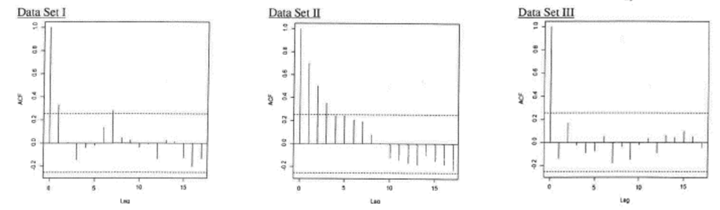

1. I only;
2. II only;
3. III only;
4. I, II and III;
5. The answer is not given by (A), (B), (C), or (D).

#### Question 2

For each of the two time series models, check stationarity and invertibility. Fully justify your answer.

1. X<sub>t</sub> = Z<sub>t</sub> − $\frac{2}{3}$Z<sub>t−1</sub> − $\frac{1}{3}$Z<sub>t−2</sub>

$$\begin{aligned}
&X_{t}\ \text{is a moving average model, MA(2)}\\
& \text{By definition, moving average models are} \\
& \text{always stationary.}\\
X_{t} &= Z_{t}-\frac{2}{3}Z_{t-1}-\frac{1}{3}Z_{t-2}\\
& = \theta(B)Z_{t}\\
& = 1 -\theta_{1}B\ Z_{t-1} - \theta_{2}B^2\ Z_{t-2}\\
& = 1- \frac{2}{3}B\ Z_{t-1} - \frac{1}{3}B^2\ Z_{t-2}\\
&\theta(z) = 1 - \frac{2}{3}z-\frac{1}{3}z^2\\
z &= \frac{-(-2/3)\ \pm\ \sqrt{(-2/3)^2-4(-1/3)(1)}}{2(-1/3)}\\ \\
&= \frac{2/3\ \pm\ \sqrt{4/9+4/3}}{-2/3}\\\\
&= -1 \pm\ \frac{\sqrt{16/9}}{-2/3}\\\\
& = -1 + \frac{-4/3}{-2/3}\ or\ -1-\frac{4/3}{-2/3}\\
& = 1\ or\ -3\\ \\
&\text{This time series is not invertible.}
\end{aligned}$$

2. X<sub>t</sub> = (2/3) X<sub>t−1</sub> + (1/3) X<sub>t−2</sub> +Z<sub>t</sub>

$$\begin{aligned}
&X_{t} = Z_{t}+\frac{2}{3}X_{t-1}+\frac{1}{3}X_{t-2}\\
&Z_{t} = X_{t}-\frac{2}{3}X_{t-1}-\frac{1}{3}X_{t-2}\\\\
& \text{Since it is of the form},\ \phi(B)X_{t} = Z_{t},\\
& \text{it is automatically invertible} \\\\
&\phi(z) = 1 - \frac{2}{3}z-\frac{1}{3}z^2\\
z &= \frac{-(-2/3)\ \pm\ \sqrt{(-2/3)^2-4(-1/3)(1)}}{2(-1/3)}\\ \\
&= \frac{2/3\ \pm\ \sqrt{4/9+4/3}}{-2/3}\\\\
&= -1 \pm\ \frac{\sqrt{16/9}}{-2/3}\\\\
& = -1 + \frac{-4/3}{-2/3}\ or\ -1-\frac{4/3}{-2/3}\\
& = 1\ or\ -3\\ \\
&\text{This time series is not stationary}
\end{aligned}$$

#### Question 3

1. For a MA(3) process with coefficients θ<sub>1</sub> = 2, θ<sub>2</sub> = 0.5, and θ<sub>3</sub> = −0.1
   (i) Write the mathematical equation for MA(3) model with these coefficients
   $$X_{t} = Z_{t}\ +\ 2\ Z_{t-1}\ +\ 0.5\
   Z_{t-2}\ -\ 0.1\ Z_{t-3}$$
   (ii) Calculate the autocorrelation function at lags 1, 2, 3, 4: ρ(1), ρ(2), ρ(3) and ρ(4)
   $$\begin{aligned}
   \rho(k) &=
   \frac{\theta_{k}+\theta_{1}\theta_{k+1}+\theta_{2}\theta_{k+2}}{1+\theta_{1}^2+\theta_{2}^2+\theta_{3}^2}\\
   \\
   \rho(1) &=
   \frac{\theta_{1}+\theta_{1}\theta_{2}+\theta_{2}\theta_{3}}{1+\theta_{1}^2+\theta_{2}^2+\theta_{3}^2}\\
   & = \frac{2+2(0.5)+0.5(-0.1)}{1+2^2+0.5^2+(-0.1)^2}\\
   & = 2.95/5.26\\
   &=0.5608 \\\\
   \rho(2) &=
   \frac{\theta_{2}+\theta_{1}\theta_{3}+\theta_{2}\theta_{4}}{1+\theta_{1}^2+\theta_{2}^2+\theta_{3}^2}\\
   &= (0.5+2(-0.1))/5.26\\
   & = 0.05703\\\\
   \rho(3) &=
   \frac{\theta_{3}+\theta_{1}\theta_{4}+\theta_{2}\theta_{5}}{1+\theta_{1}^2+\theta_{2}^2+\theta_{3}^2}\\
   &= -0.1/5.26\\
   &= -0.019\\\\
   \rho(4) &=
   \frac{\theta_{4}+\theta_{1}\theta_{5}+\theta_{2}\theta_{6}}{1+\theta_{1}^2+\theta_{2}^2+\theta_{3}^2}\\
   &=0\\
   &\rho_X(k)=0, \ k>q
   \end{aligned}$$
2. For an AR(1) process with coefficient $\phi$<sub>1</sub> = −0.5, (i) Write the mathematical equation for AR(1) model with these coefficients
   $$X_{t} = -0.5\ X_{t-1} + Z_{t}$$
   (ii) Calculate the autocorrelation function at lags 1, 2, 3, 4: ρ(1), ρ(2), ρ(3) and ρ(4)
   $$\begin{aligned}
   & \rho_{X}(k) = \phi_{1}^k\\
   & \rho(1)= -0.5\\
   & \rho(2)= 0.25\\
   & \rho(1)= -0.125\\
   & \rho(1)= 0.0625\\
   \end{aligned}$$

#### Question 4

You are given the following process: X<sub>t</sub> = 3 + Y + Z<sub>t</sub>, where Y is a mean zero random variable with variance σ<sub>Y</sub><sup>2</sup>, independent of the white noise {Z<sub>t</sub>}. Determine whether the process X is stationary and find its autocovariance and autocorrelation functions.

$$
$$\begin{aligned}
&X_{t}=3+Y+Z_{t}\\\\
E[X_{t}]&=E[3+Y+Z_{t}]\\
&= E[3]+E[Y]+E[Z_{t}]\\
&= 3 + 0 + 0 = 3 \\\\
& \text{Given that Y is independent from}\ Z_{t},\\
Var[X_{t}] &= Var[3+Y+Z_{t}]\\
&= Var[Y + Z_{t}]\\
&= Var[Y] + Var[Z_{t}] \\
Var[X_t] &= \sigma_{Y}^2 + \sigma_{Z}^2\\
& \text{Since}\ Var[X+Y]=Var[X]+Var[Y]\ \text{if X and Y are
independent} \\\\
Cor(X_{t}) = &Cor(3+Y+Z_{t})\\
& \gamma_{X}(0) = Cov(X_{t}, X_{t}) = Var(X_{t})\\
& \text{is independent of all t}
\end{aligned}$$

#### Question 5

Let X<sub>t</sub> = Z<sub>t</sub> + 2Z<sub>t−1</sub> − 8Z<sub>t−2</sub>.

1. Identify the model as the model as MA(q) or AR(p), specify q or p respectively.

$$\begin{aligned}
MA(2)
\end{aligned}$$

2. Is the model stationary and invertible? Explain fully and show calculations where needed. | (Hint: review 4 from homework 1!)
   $$\begin{aligned}
   &\text{All moving average models are stationary.}\\
   &\text{Since}\ \theta_{1} = 2,\ \&\ \theta_{2} = -8,\\
   & |\theta_{2}| > |\theta_{1}| > 1\\
   & \text{The model is not invertible.}
   \end{aligned}$$
3. Find ρ<sub>X</sub>(2). Use R to simulate 300 values of {X<sub>t</sub>} and use your simulated values to plot sample acf. Compare your sample estimate of ρ<sub>X</sub>(2) to its true value found by calculations. Redo this part using 10,000 simulated values of X<sub>t</sub>.

$$\begin{aligned}
\rho_{X}(2) &=
\frac{\theta_{2}+\theta_{1}\theta_{3}}{1+\theta_{1}^2+\theta_{2}^2}\\\\
&= -8/(1+2^2+(-8)^2)\\
&= -8/69\\
&=-0.1159
\end{aligned}$$

```r
Z_t <- rnorm(300,0,1)
X_t <- Z_t
X_t[1] = Z_t[1]
X_t[2] = Z_t[2]+2*Z_t[1]
X_t[3:300] = Z_t[3:300]+2*Z_t[2:299]-8*Z_t[1:298]
acf(X_t, lag=2, plot = FALSE)[[1]][[3]]
```

```
## [1] -0.01209544
```

```r
Z_t <- rnorm(10000,0,1)
X_t <- Z_t
X_t[1] = Z_t[1]
X_t[2] = Z_t[2]+2*Z_t[1]
X_t[3:10000] = Z_t[3:10000]+2*Z_t[2:9999]-8*Z_t[1:9998]
acf(X_t, lag=2, plot = FALSE)[[1]][[3]]
```

```
## [1] -0.119915
```

**The following problems are for students enrolled in PSTAT 274 ONLY**

#### Question G1

Let{Z<sub>t</sub>}∼WN(0,1) and {X<sub>t</sub>} be given by X<sub>t</sub> =Z<sub>t</sub>+θZ<sub>t−2</sub>

1. Find the autocovariance and autocorrelation function for this process when θ = 0.8
   $$\begin{aligned}
   \gamma_{x}(k)&=
   \begin{cases}1+\theta_{2}^2\ \ \ \ \ \ \ \ for\ \ k = 0\\ \theta_{k}\ \
   \ \ \ \ \ \ \ \ \ \ \ \ for\ \ k=2\\ 0 \ \ \ \ \ \ \ \ \ \ \ \ \ \ \
   otherwise \end{cases} \\\\
   &= \begin{cases}1.64\ \ \ \ \ \ \ \ for\ \ k = 0\\ 0.8\ \ \ \ \ \ \
   \ \ \ for\ \ k=2\\ 0 \ \ \ \ \ \ \ \ \ \ \ \ \ otherwise \end{cases}
   \\\\
   \rho_{X}(k) &=
   \begin{cases}1\ \ \ \ \ \ \ \ \ \ \ for\ \ k=0\\
   \frac{\theta_{k}}{1+\theta_{2}^2}\ \ \ \ \ for\ \ k=\pm 2\\ 0 \ \ \ \ \
   \ \ \ \ \ \ otherwise \end{cases} \\\\
   &= \begin{cases}1\ \ \ \ \ \ \ \ \ \ \ \ \ \ for\ \ k=0\\ 0.4878\ \
   \ \ \ for\ \ k=\pm 2\\ 0 \ \ \ \ \ \ \ \ \ \ \ \ \ \ otherwise
   \end{cases}
   \end{aligned}$$
2. Compute the variance of the sample mean (X<sub>1</sub> + X<sub>2</sub> + X<sub>3</sub> + X<sub>4</sub>)/4 when θ = 0.8
   $$\begin{aligned}
   \theta = 0.8\\\\
   Var[\frac{X_{1}+X_{2}+X_{3}+X_{4}}{4}] &= (Var[X_{1}]+ Var[X_{2}]+
   Var[X_{3}]+ Var[X_{4}]+ 2Cov[X_{2}, X_{4}] + 2Cov[X_{1}, X_{3}])/16\\\\
   Var[X_{t}] = \sigma_{Z}^2(1 + \theta^2), &\ \ \ \ \ \ \ \ \ \ \ \ \
   Cov(X_{t}, X_{t+k}) = \sigma_{Z}^2(\theta_{k})\\
   &=\frac{1}{16}\ [4(1+\theta_{2}^2) + 4\theta]\\
   &=\frac{1+\theta_{2}^2+\theta_{2}}{4}\\\\
   &=[1+0.64+0.8]/4\\
   &=0.61
   \end{aligned}$$
3. Repeat (b) when θ = −0.8 and compare your answer with the result obtained in (b)

#### Question G2

Provide at least two examples of AR(2) models with autocovariance functions exhibiting very different behavior pattern. Include plots of corresponding theoretical acfs and the corresponding R code.

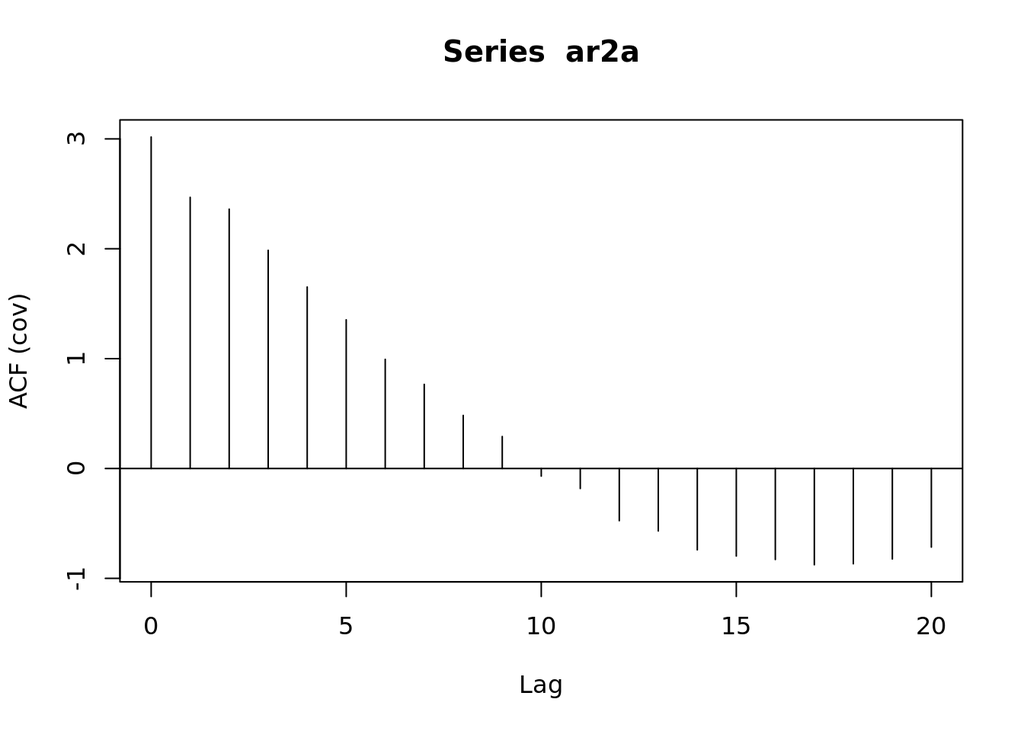

```r
ar2a <- arima.sim(model=list(ar=c(0.5, 0.4)), n=100, sd=1)
acf(ar2a, type="covariance")
```

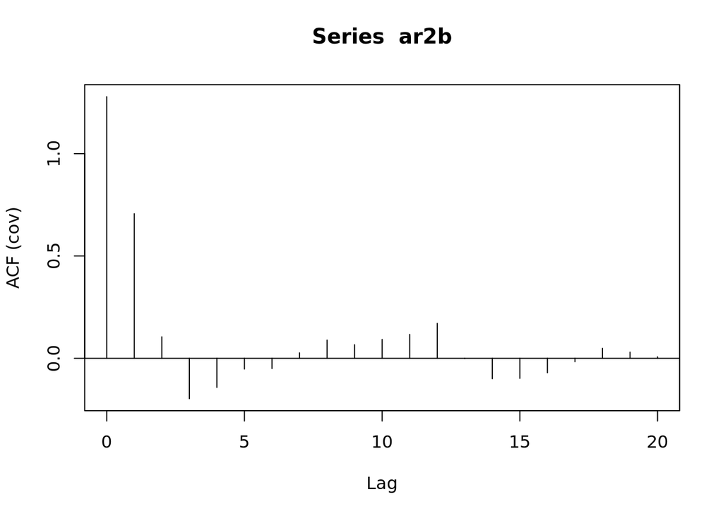

```r
ar2b <- arima.sim(model=list(ar=c(0.8, -0.4)), n=100, sd=1)
acf(ar2b, type="covariance")
```

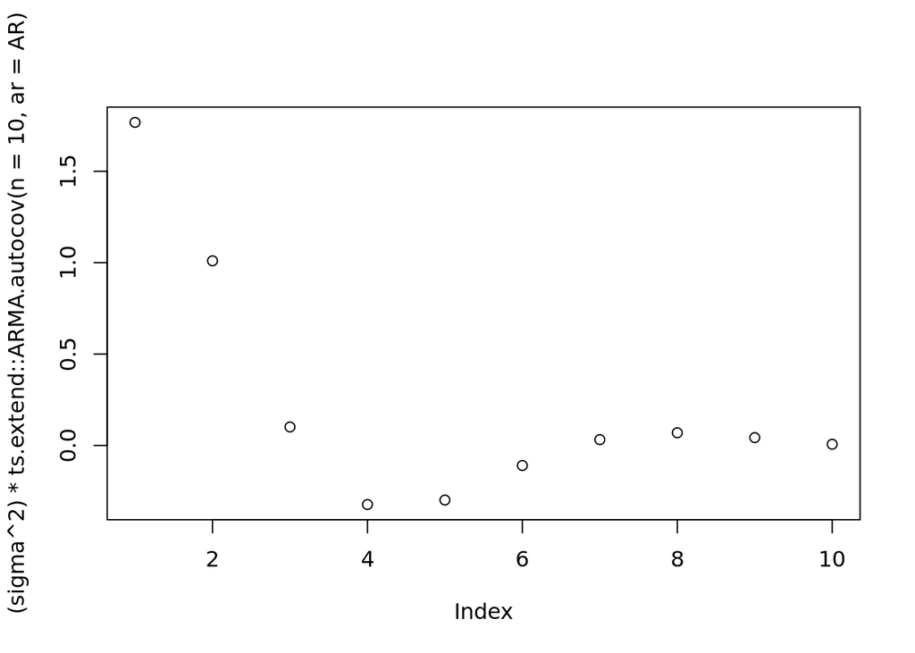

```r
#Set the parameters
AR    <- c(0.8, -0.4)
sigma <- 1

#Compute auto-covariance function up to length n
plot((sigma^2)*ts.extend::ARMA.autocov(n = 10, ar = AR))
```

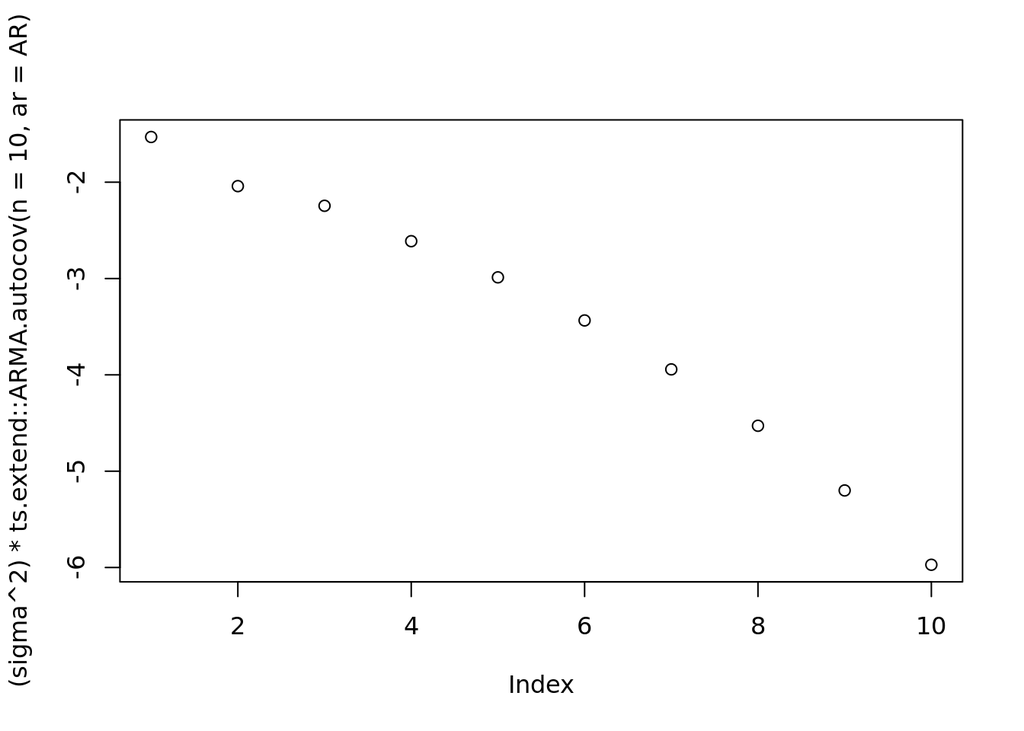

```r
#Set the parameters
AR    <- c(0.8, 0.4)
sigma <- 1

#Compute auto-covariance function up to length n
plot((sigma^2)*ts.extend::ARMA.autocov(n = 10, ar = AR))
```

#### Question G3

Let X<sub>t</sub> = Z<sub>t</sub> + θZ<sub>t−1</sub>, t = 1,2,…, where Z<sub>t</sub> ∼ IID(0,σ<sub>Z</sub><sup>2</sup>). Show that X<sub>t</sub> is both weakly and strictly stationary.  
(Hint: for the last part express the joint moment generating function E $exp(\sum_{i=1}^{n} \lambda_iX_i)$ in terms of function m(λ) = E exp(λZ<sub>i</sub>).)

$$\begin{aligned}
E[X_{t}] &= E[Z_{t}+\theta Z_{t-1}]\\
&=E[Z_{t}] + \theta E[Z_{t-1}]\\
&= 0+\theta *0\\
&=0\\\\
&\text{If}\ Z_{t}\ \&\ Z_{s}\ \text{are independent,}\\
&\text{then}\ Cov(Z_{t},\ Z_{s}) = 0,\ \text{for}\ t\ne s\\\\
Cov[X_{t}, X_{t+k}] &= Cov[Z_{t} + \theta Z_{t-1}, Z_{t+k} + \theta
Z_{t+k-1}]\\
&= \theta\ Cov[Z_{t}, Z_{t+k-1}] + Cov[Z_{t}, Z_{t+k}] + \\
& \ \ \ \ \ \theta^2\ Cov[Z_{t-1}, Z_{t+k-1}] + \theta\ Cov[Z_{t-1},
Z_{t+k}]\\
&=0\\\\
&\text{Since neither the expected value nor the covariance relies on
t,}\\
&\text{this time series is weakly stationary}
\end{aligned}$$
$$
$$\begin{aligned}
E\ [e^{\sum_{i=1}^{n} \lambda_iX_i}] &= E[e^
{\lambda_1X_1+\lambda_2X_2+...+\lambda_nX_n}]\\
&=E[e^{\lambda_1X_1}\ *\ e^{\lambda_2X_2}\ *\ ...\ *\
e^{\lambda_nX_n}]\\
M(\lambda)&=E[e^{\lambda_1(Z_{1}+\theta Z_{0})}\ *\
e^{\lambda_2(Z_{2}+\theta Z_{1})}\ *\ ...\ *\ e^{\lambda_n(Z_{n}+\theta
Z_{n-1})}]\\
&=E[e^{(\lambda_1\theta)Z_{0}}]\ *\
E[e^{(\lambda_1+\lambda_2\theta)Z_{1}}] *\
E[e^{(\lambda_2+\lambda_3\theta)Z_{2}}]*\
E[e^{(\lambda_{n-1}+\lambda_n\theta)Z_{n-1}}]*\ E[e^{\lambda_nZ_{n}}]\\
&=M_{Z_{0}}(\lambda_{1}\theta)\ M_{Z_{1}}(\lambda_{1} +
\lambda_{2}\theta)\ M_{Z_{1}}(\lambda_{2} + \lambda_{3}\theta)\
M_{Z_{n-1}}(\lambda_{n-1} + \lambda_{n}\theta)\ M_{Z_{n}}(\lambda_{n})\\
&= M_{Z_{i}}(\lambda_{i}+\lambda_{i+1}\theta)\ \ \ \ iid\\\\
\text{Therefore, }& \text{the time series is strictly stationary.}
\end{aligned}$$

$$ Thus, the time series is both weakly stationary and strictly stationary.